# SQUIDSIM, SQUID SIMULATOR, Version 1.32, SPRFMO SC13

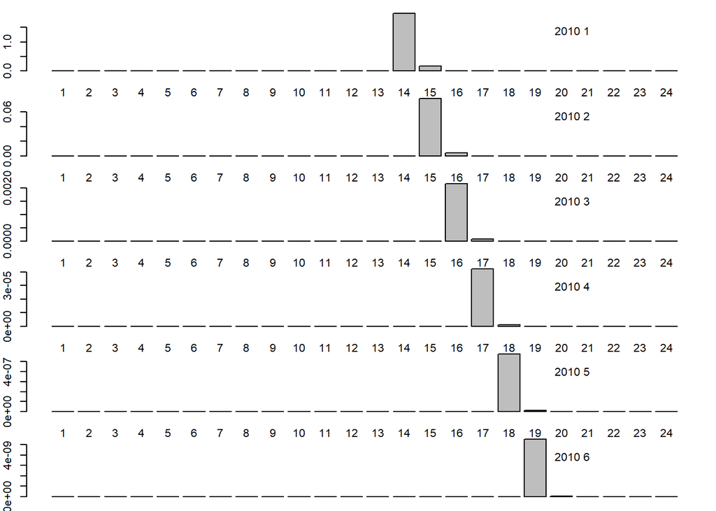

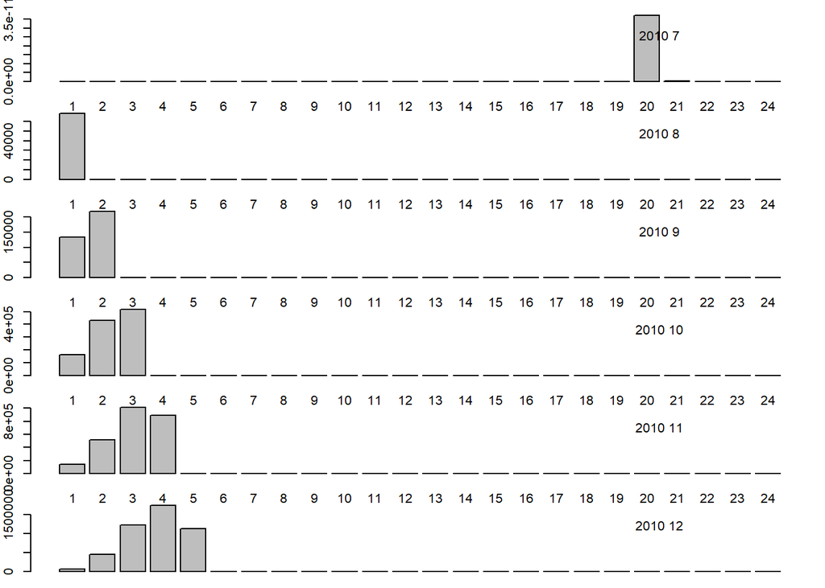

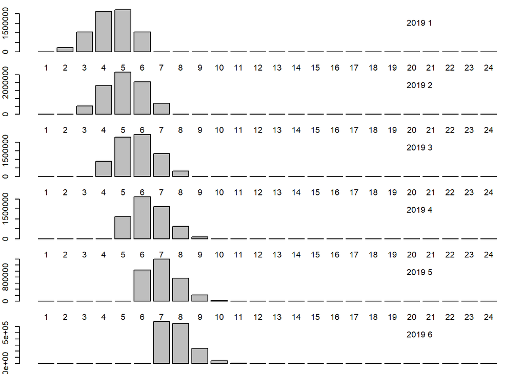

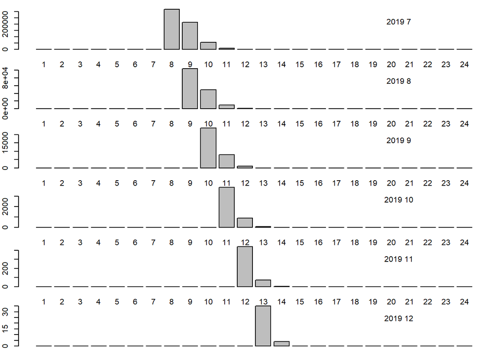

### 4.2.12 Figure 14. Fleet 2 Catch in number at age by YEAR.MONTH.

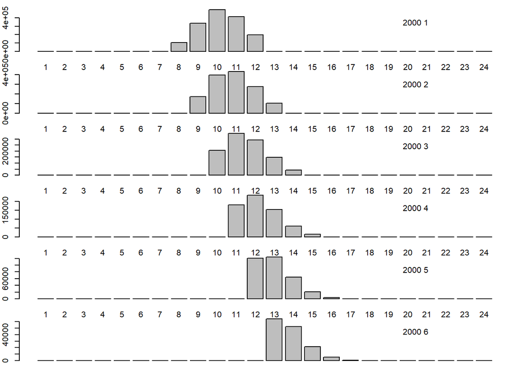

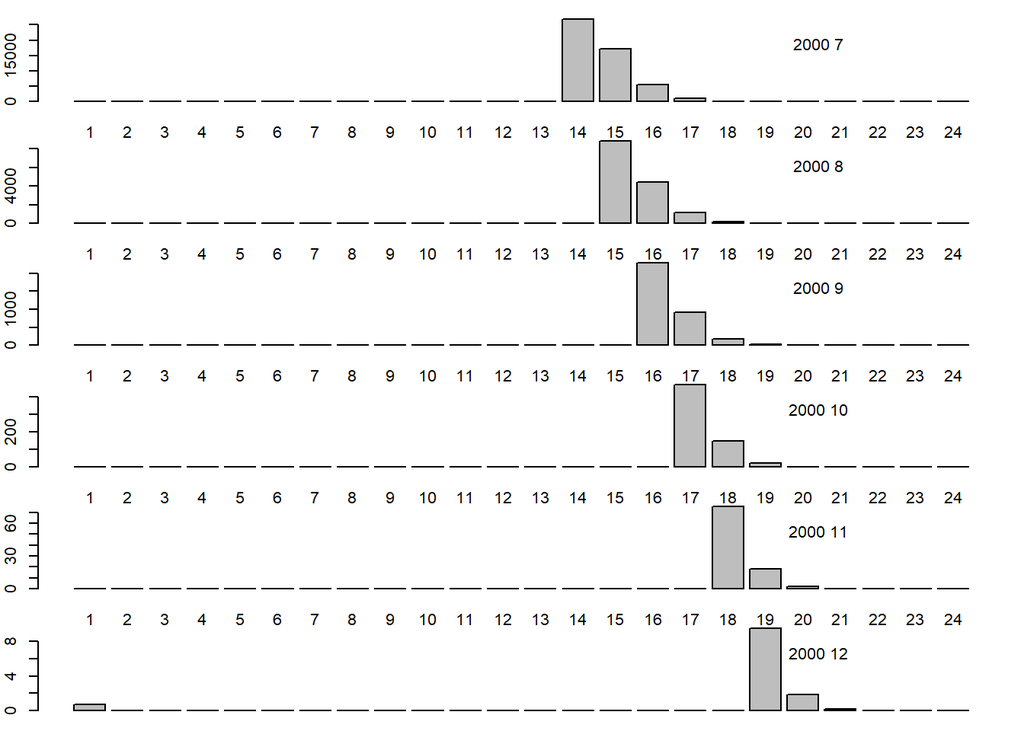

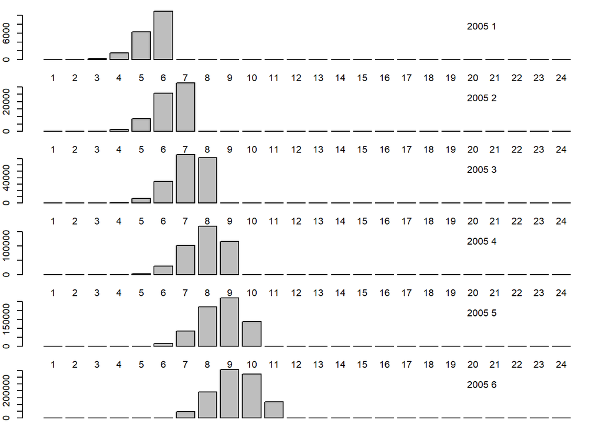

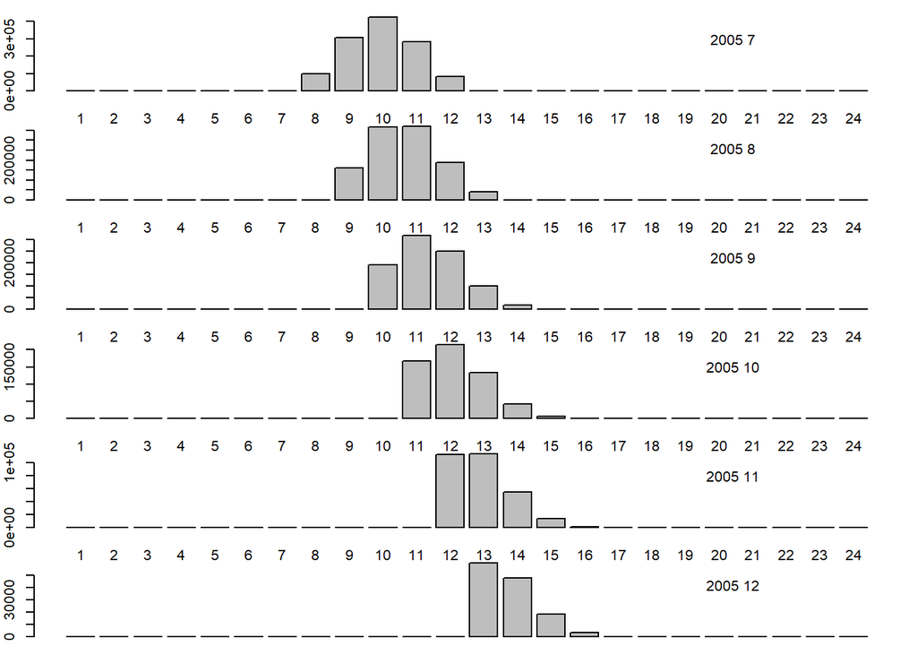

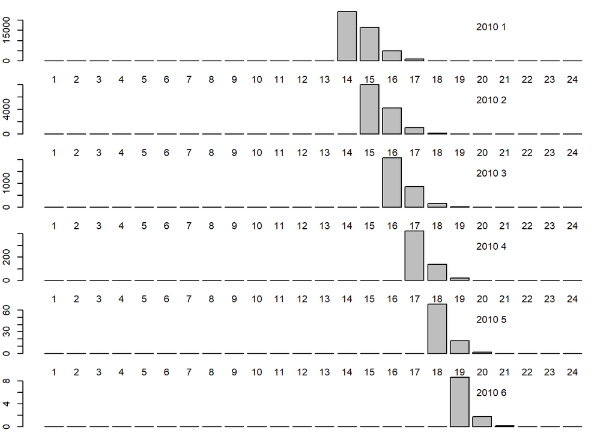

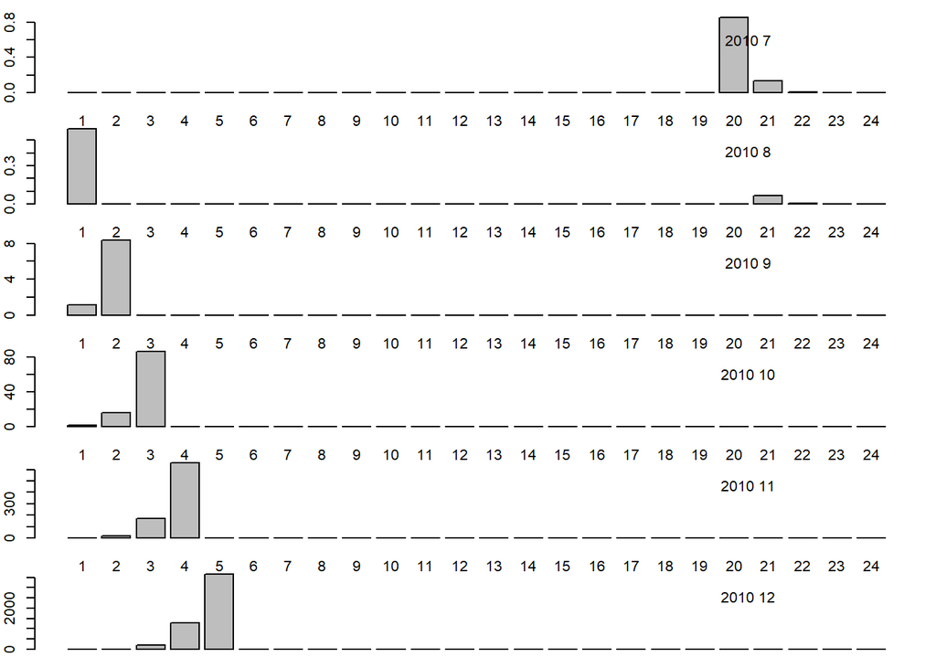

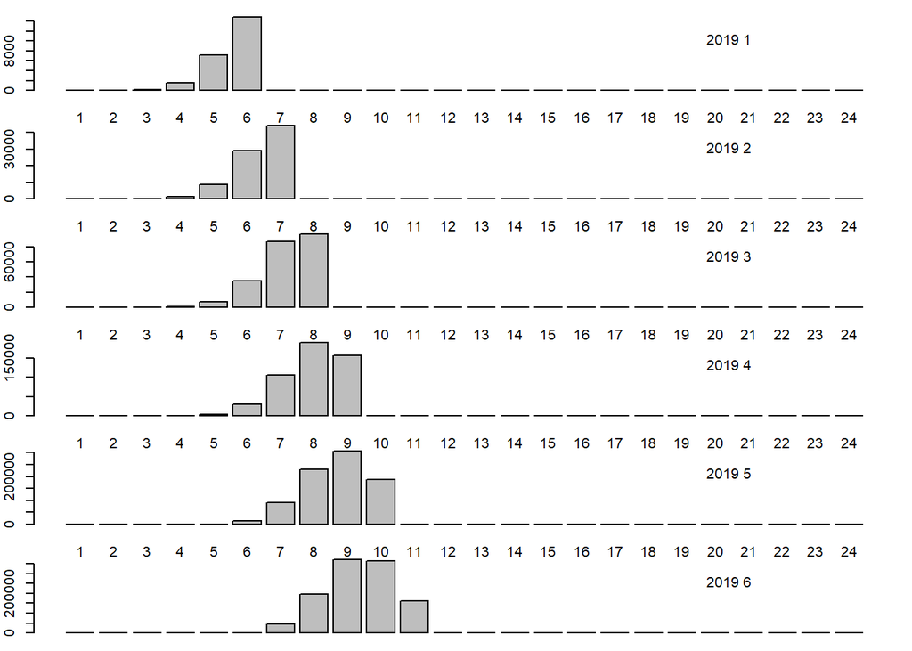

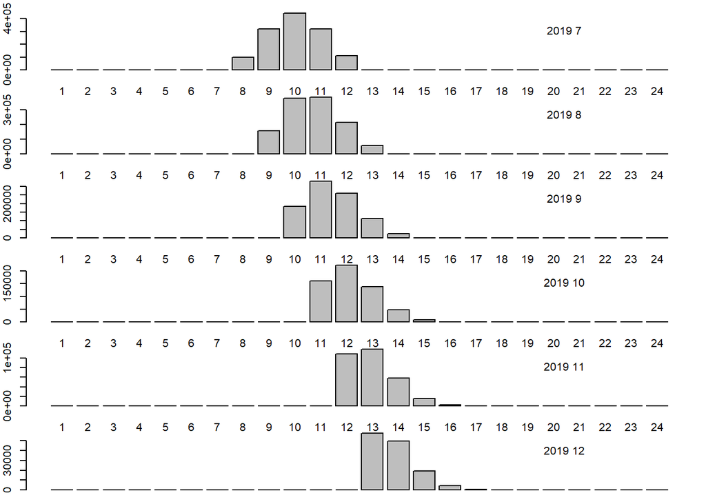

### 4.2.13 Figure 15. Fleet 3 Catch in number at age by YEAR.MONTH.

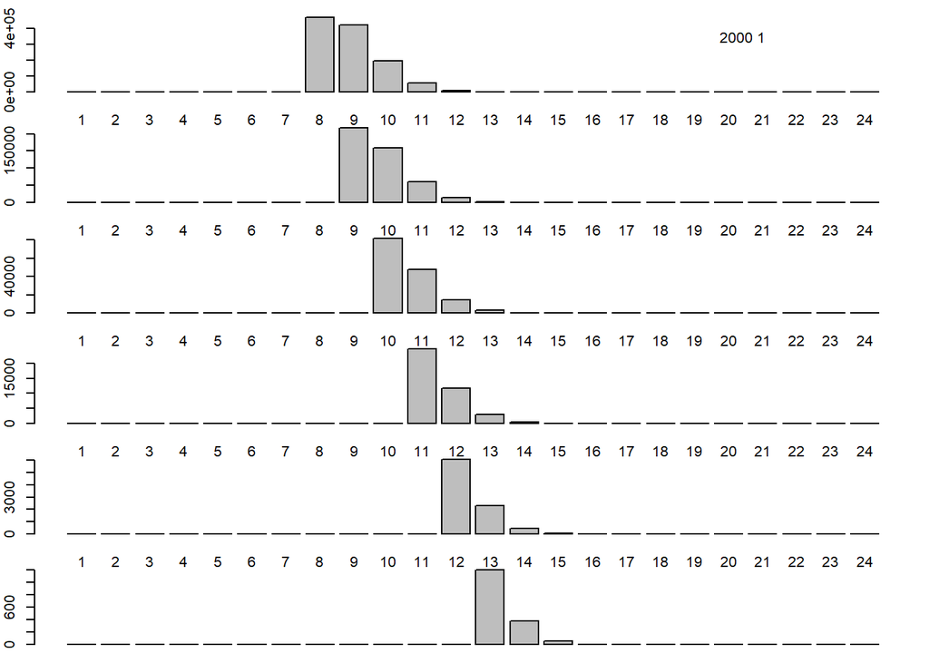

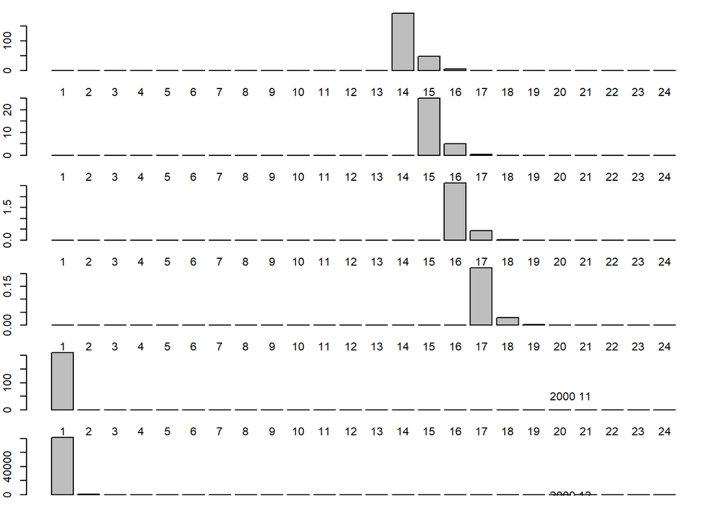

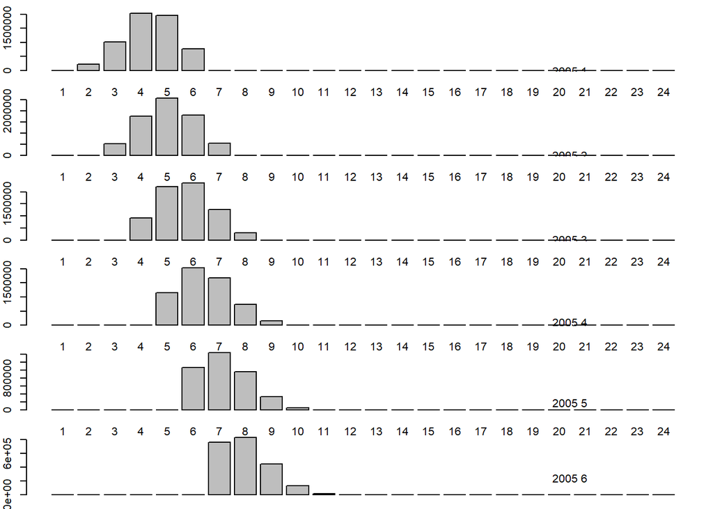

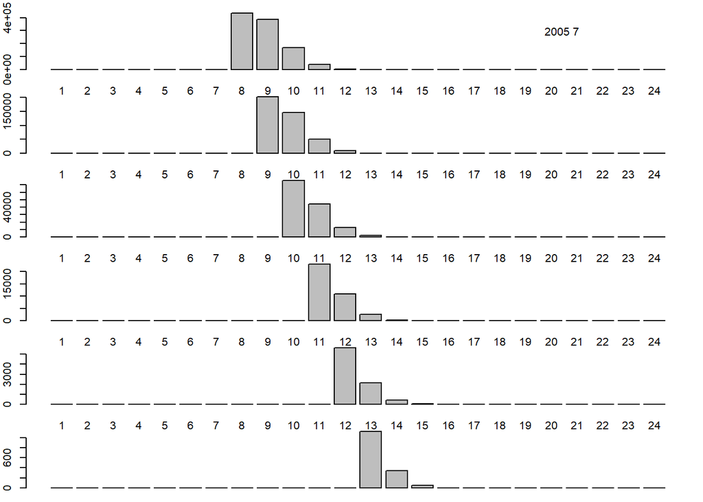

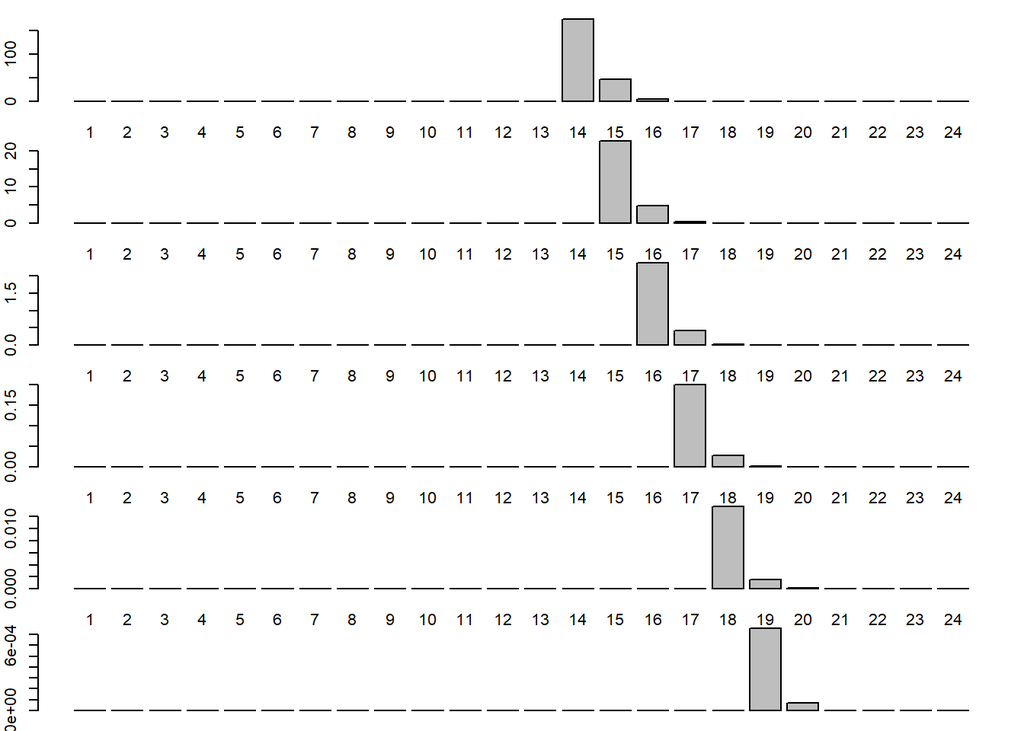

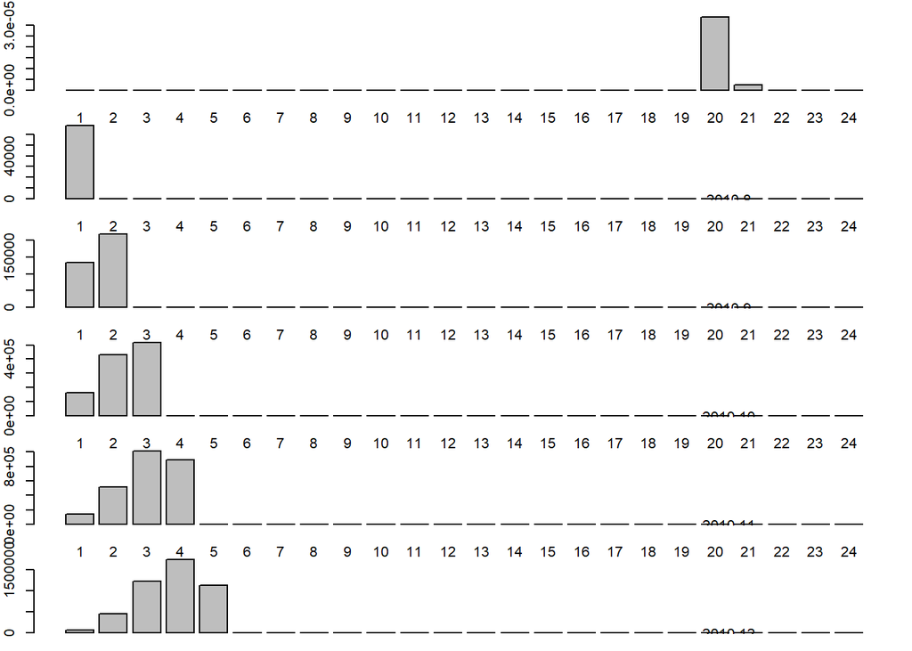

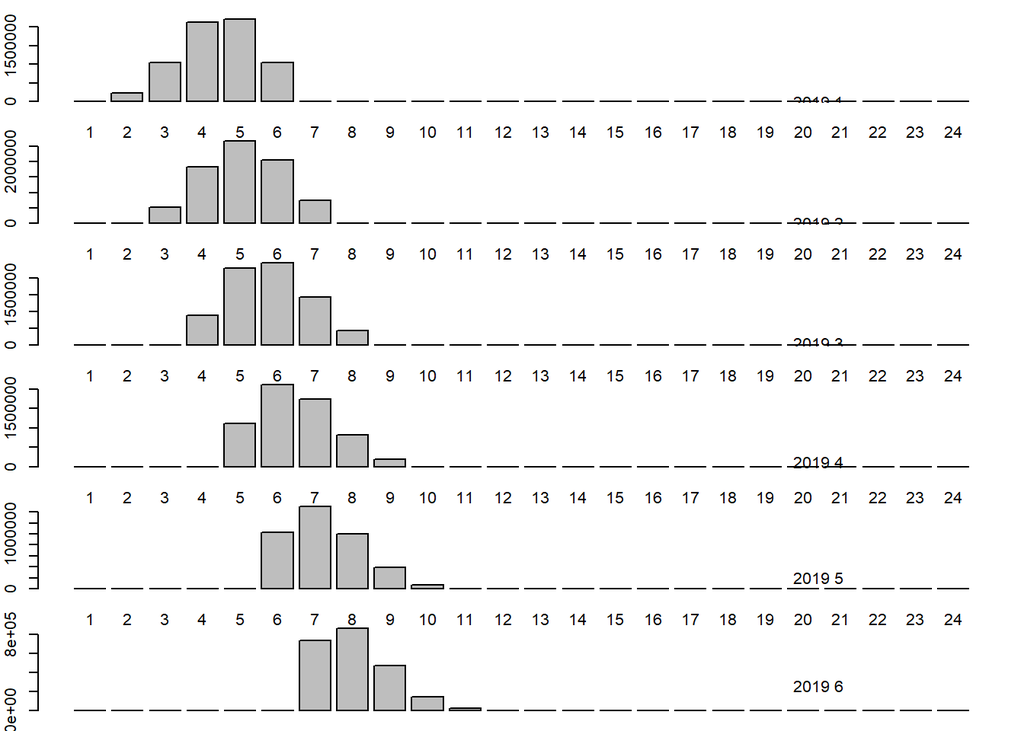

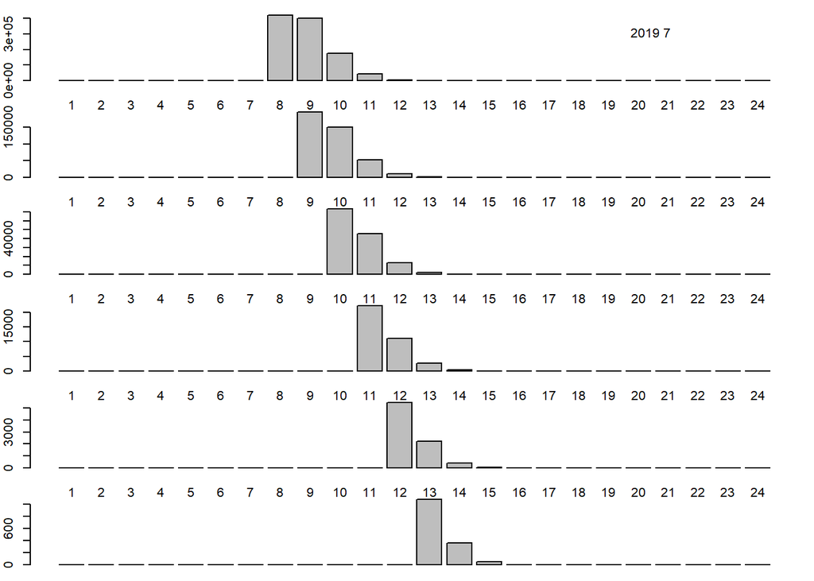

### 4.2.14 Figure 15b. Fleet 4 Catch in number at age by YEAR.MONTH.

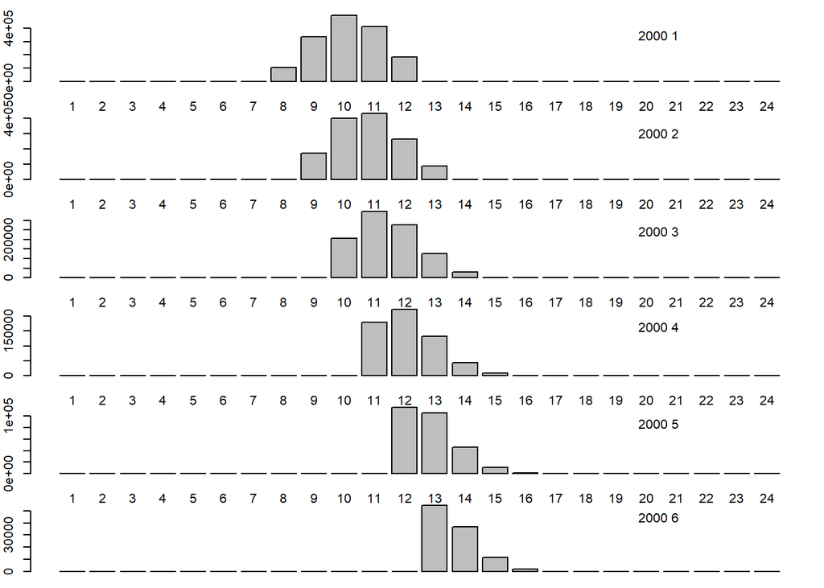

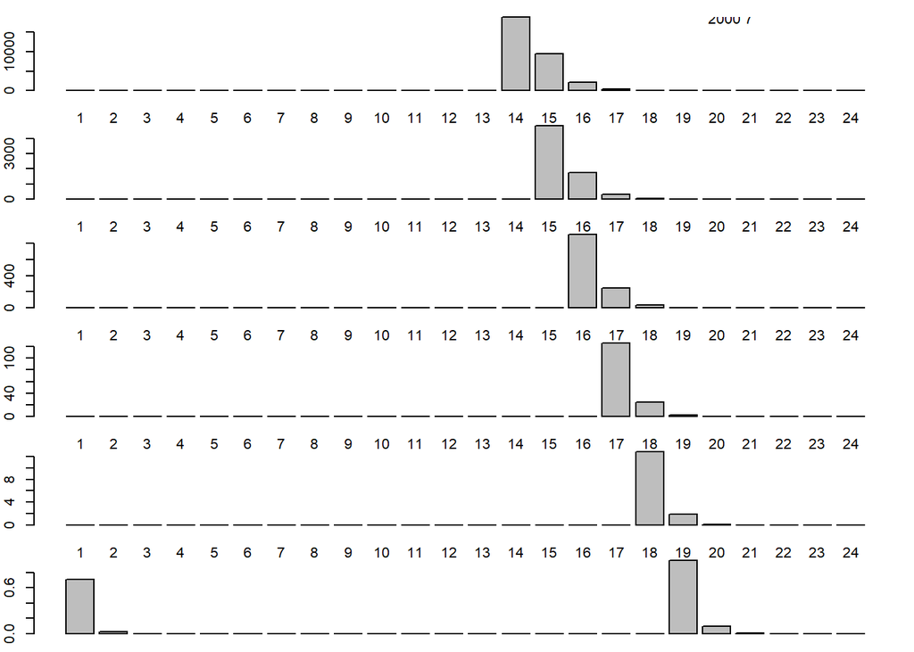

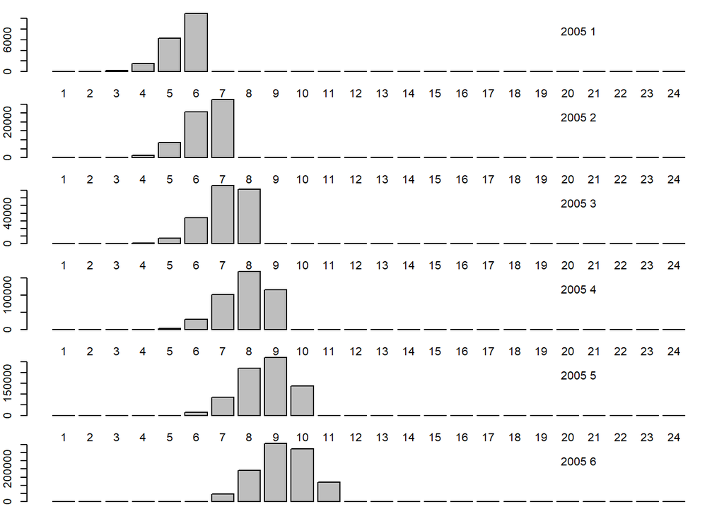

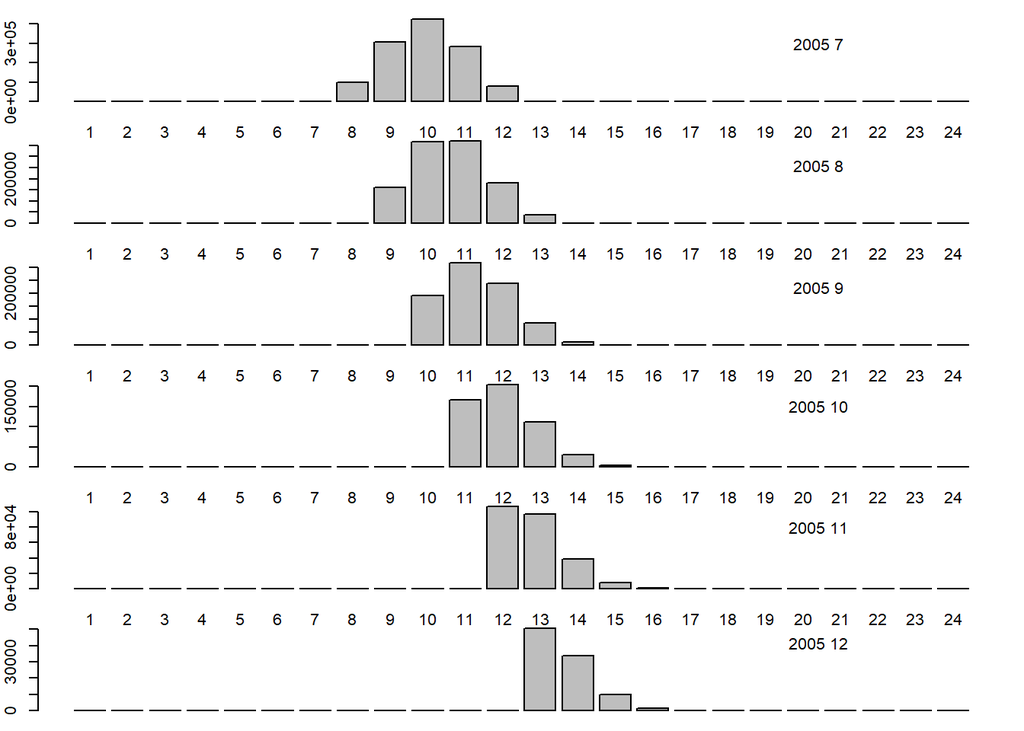

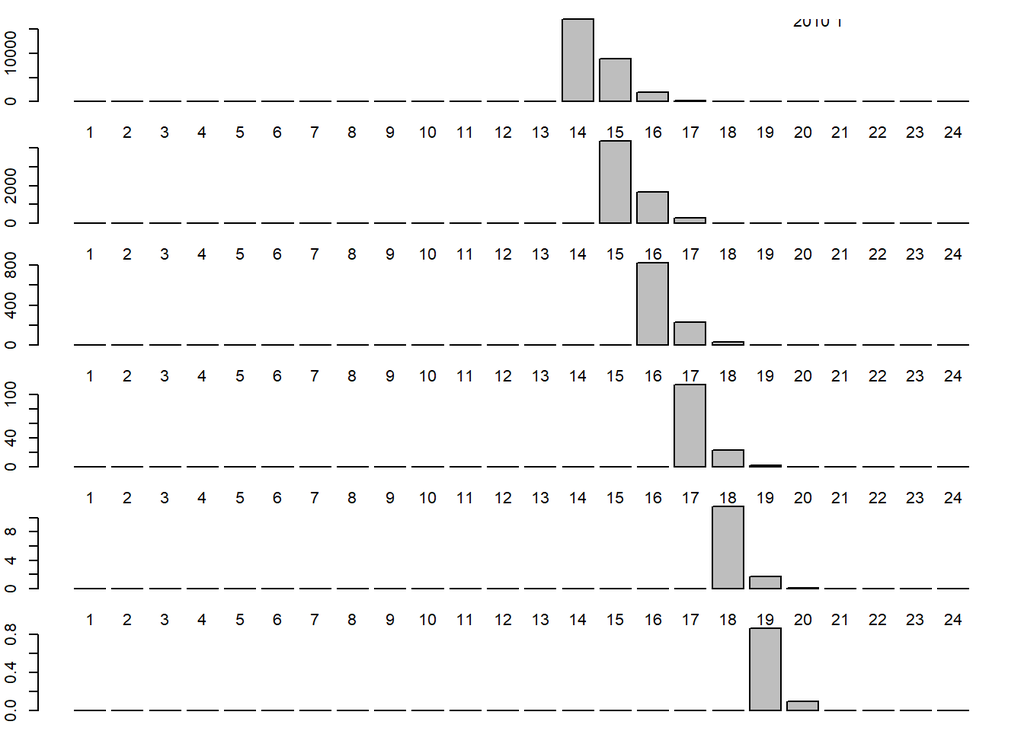

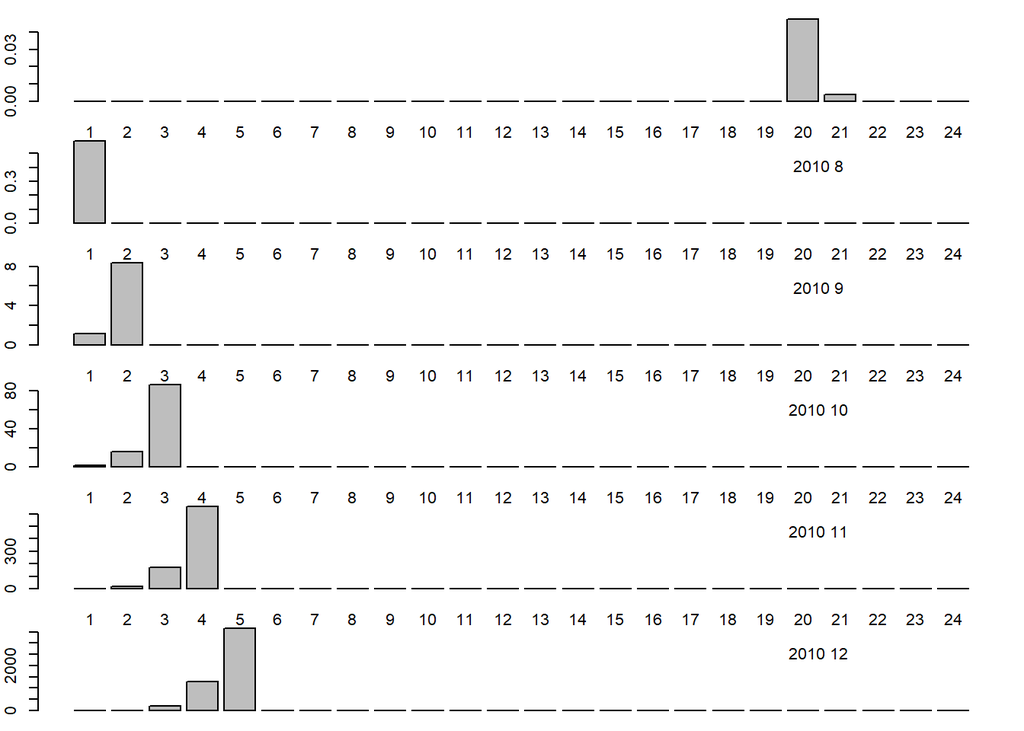

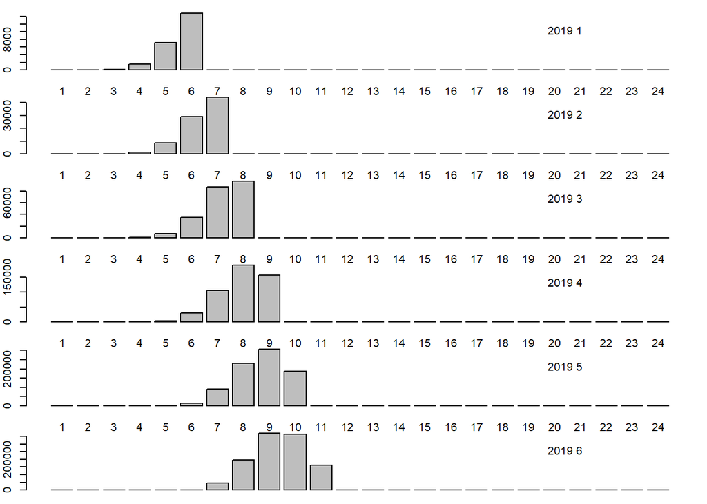

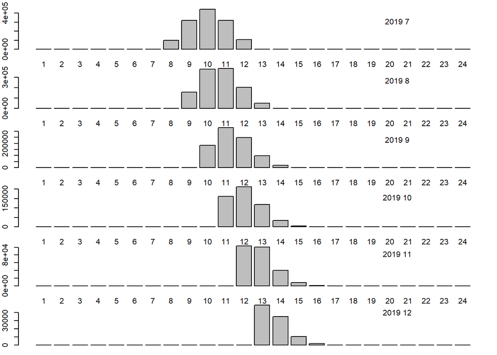

##### 4.2.14.0.1

### 4.2.15 Figure 16. Length-age key.

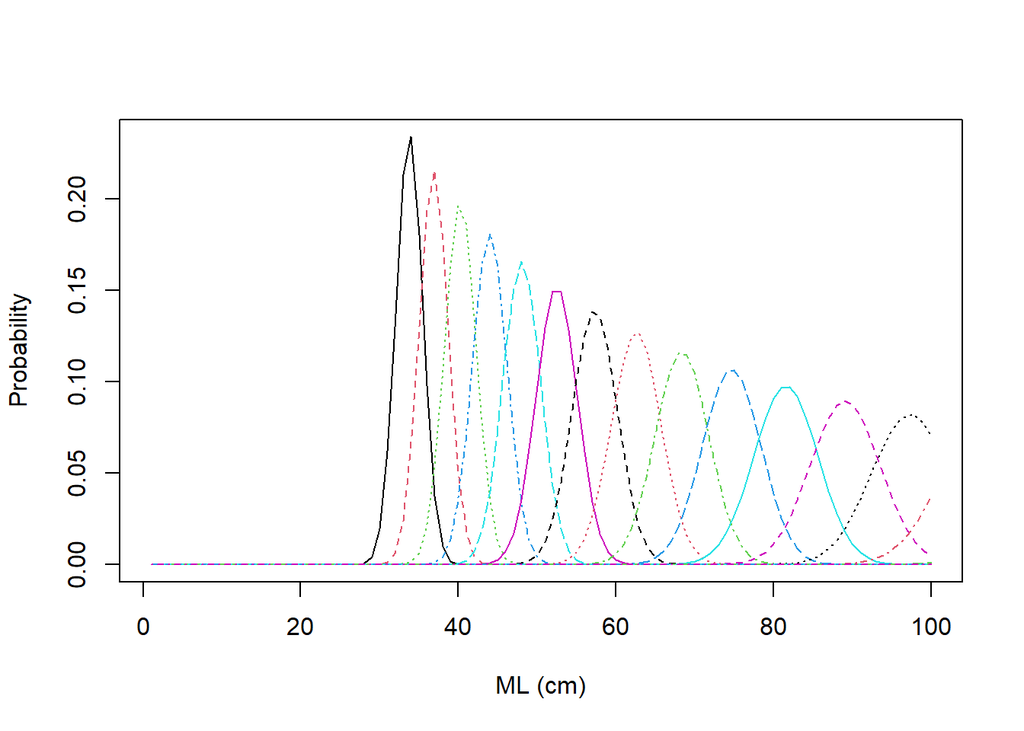

##### 4.2.15.0.1

### 4.2.16 Figure 17. Length frequency by YEAR.MONTH.

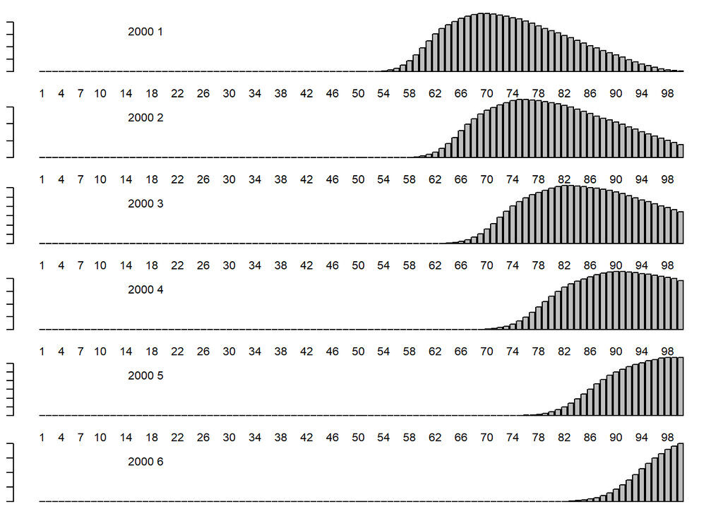

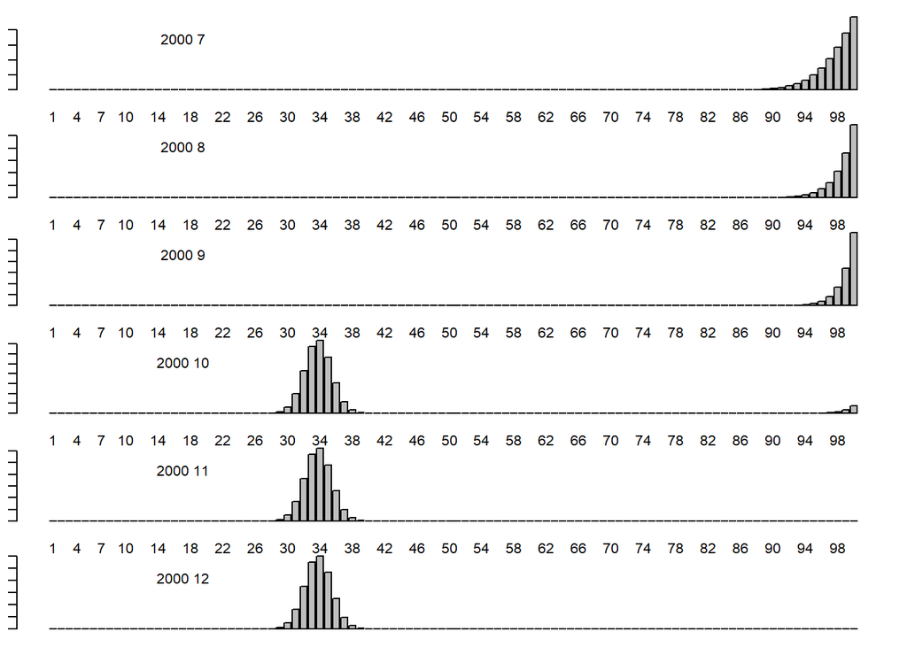

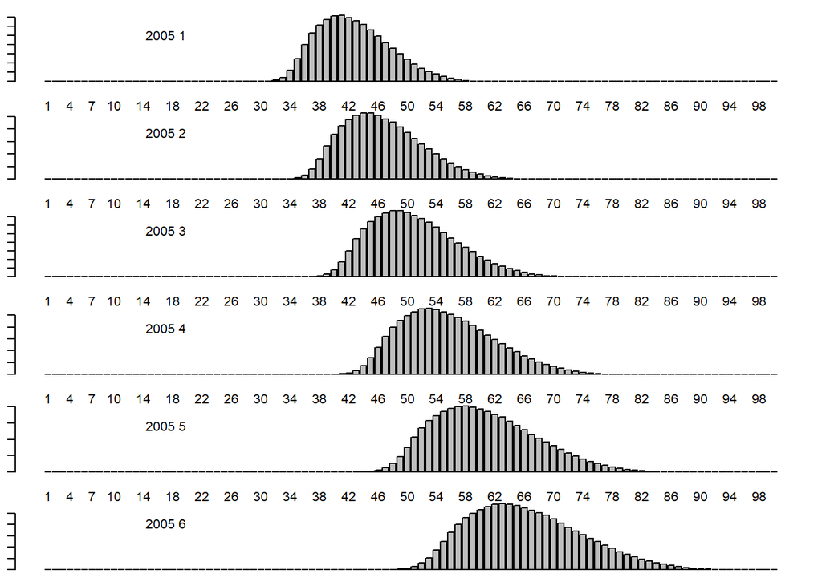

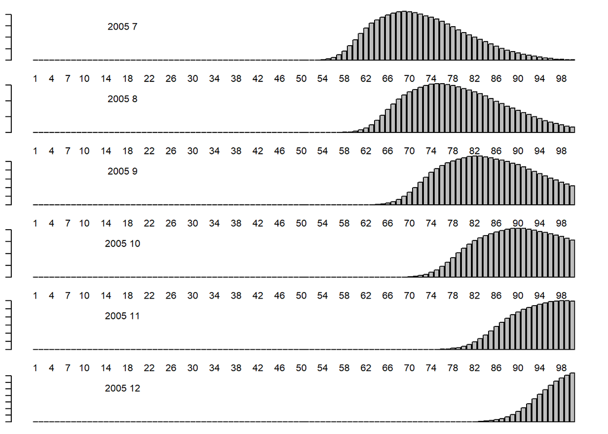

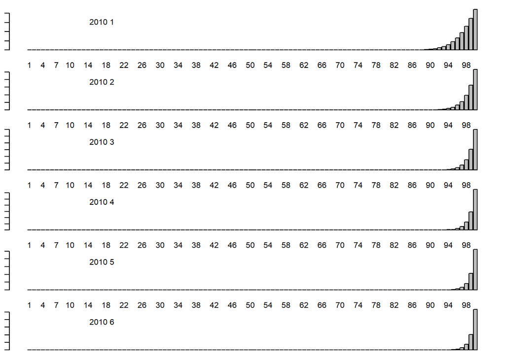

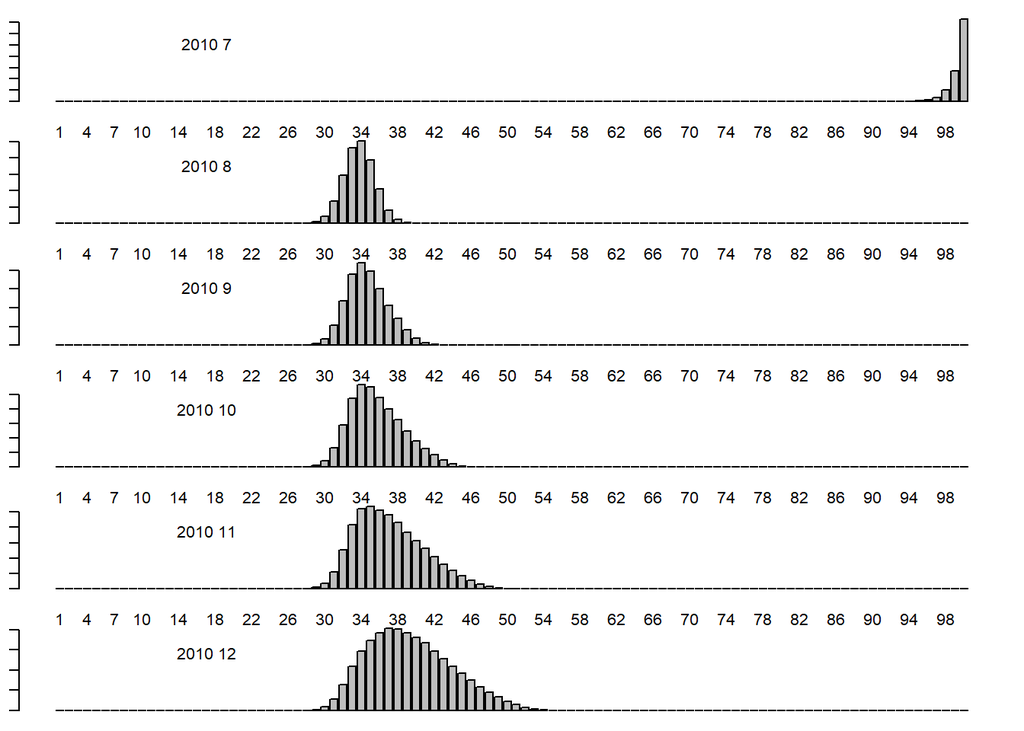

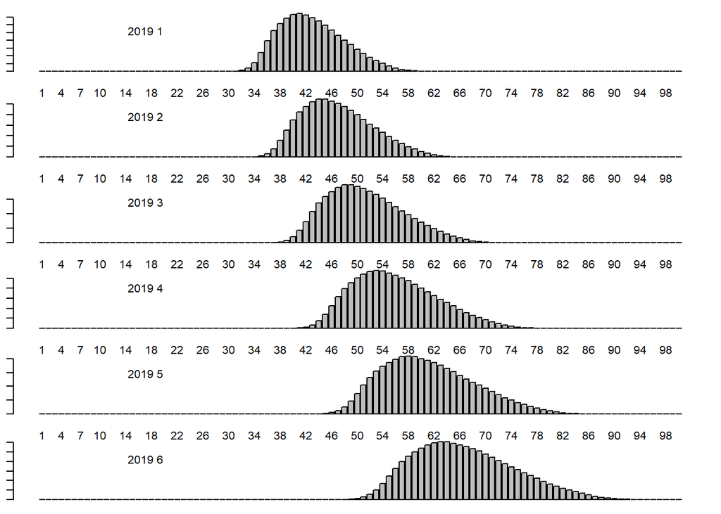

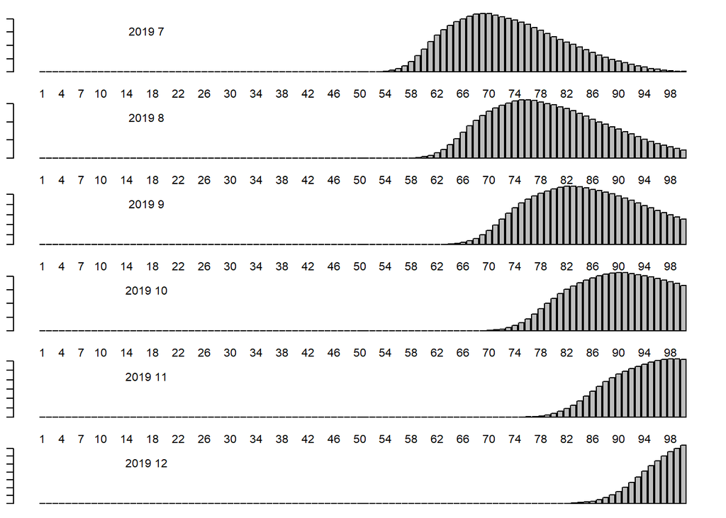

##### 4.2.16.0.1

### 4.2.17 Figure 18. Whole Catch in number at length by YEAR.MONTH.

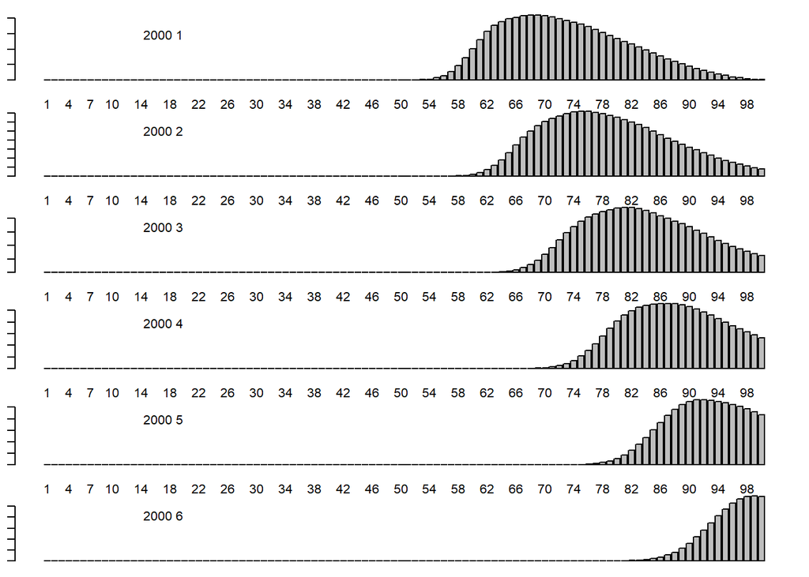

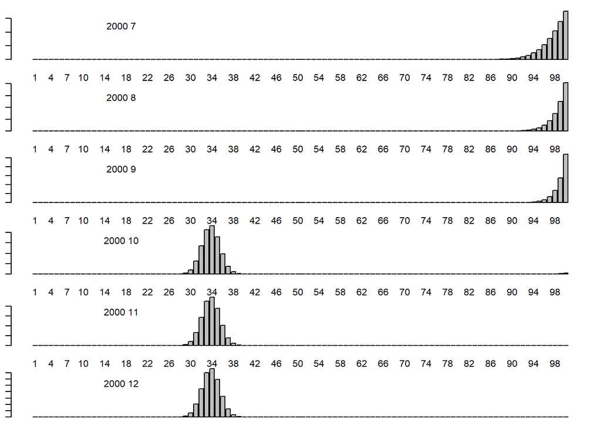

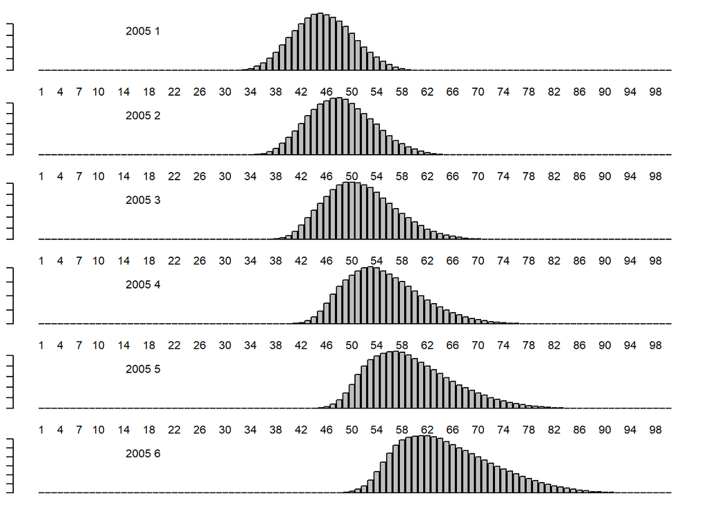

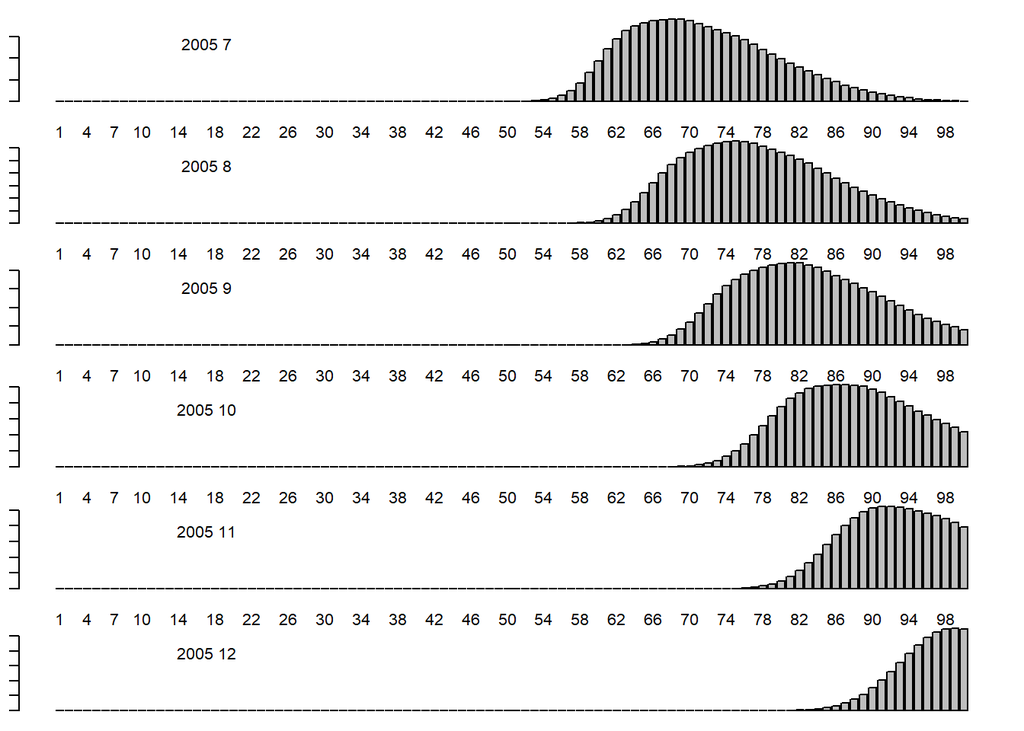

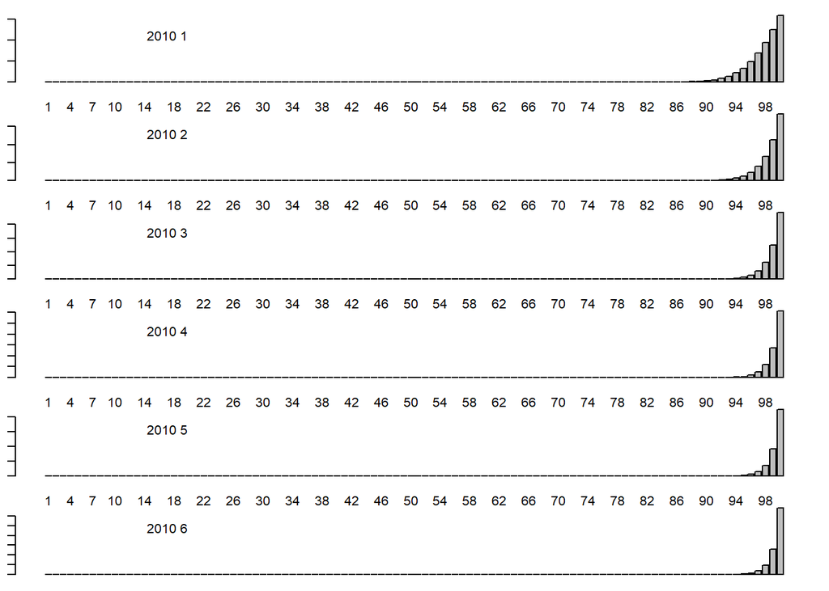

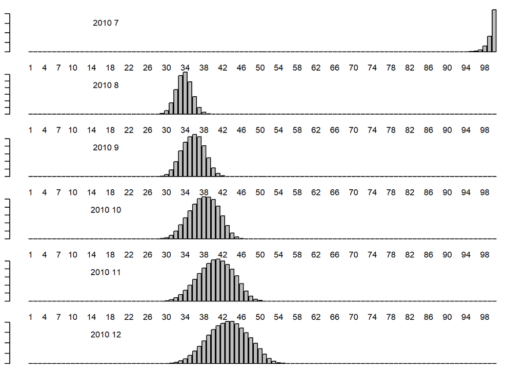

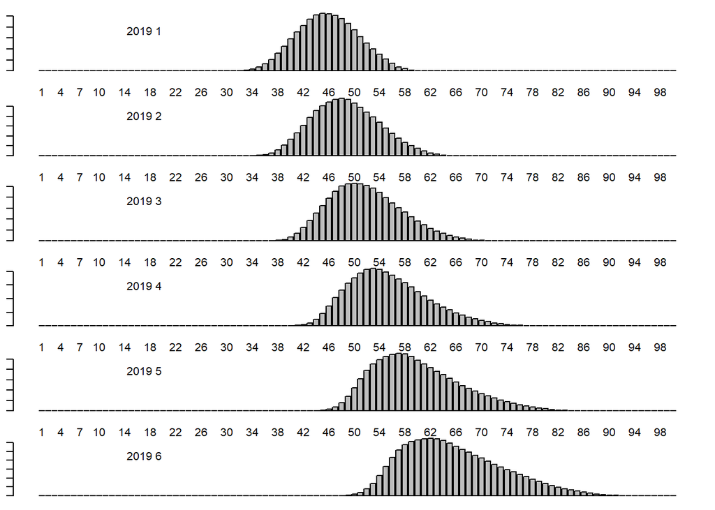

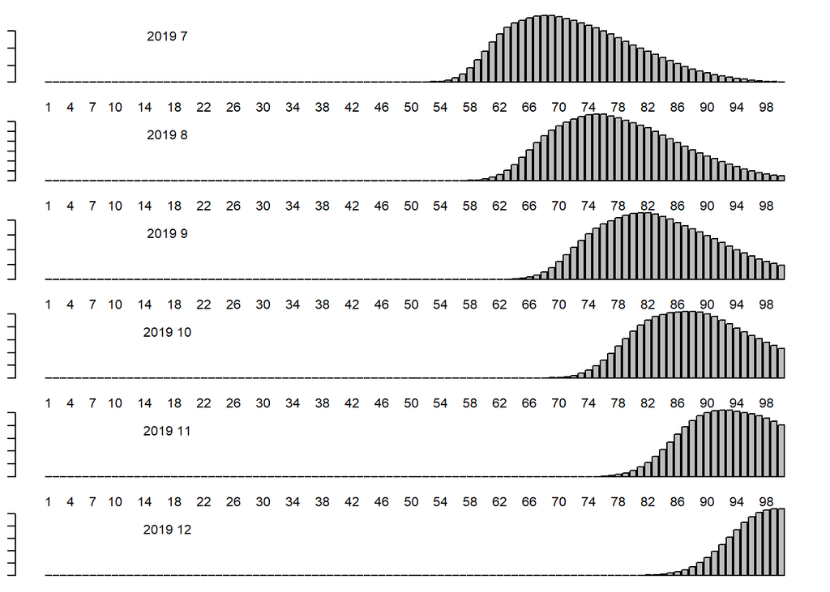

##### 4.2.17.0.1

### 4.2.18 Figure 19. Fleet 1 Catch in number at length by YEAR.MONTH.

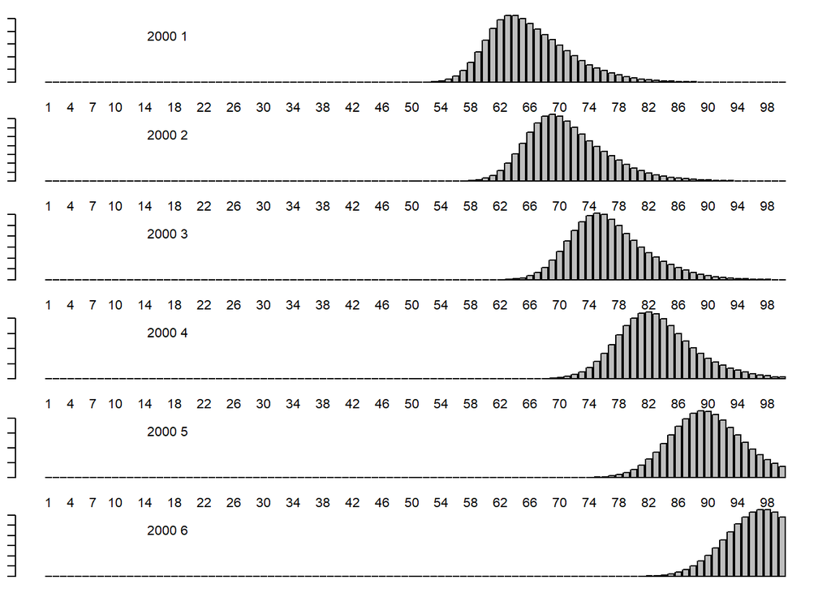

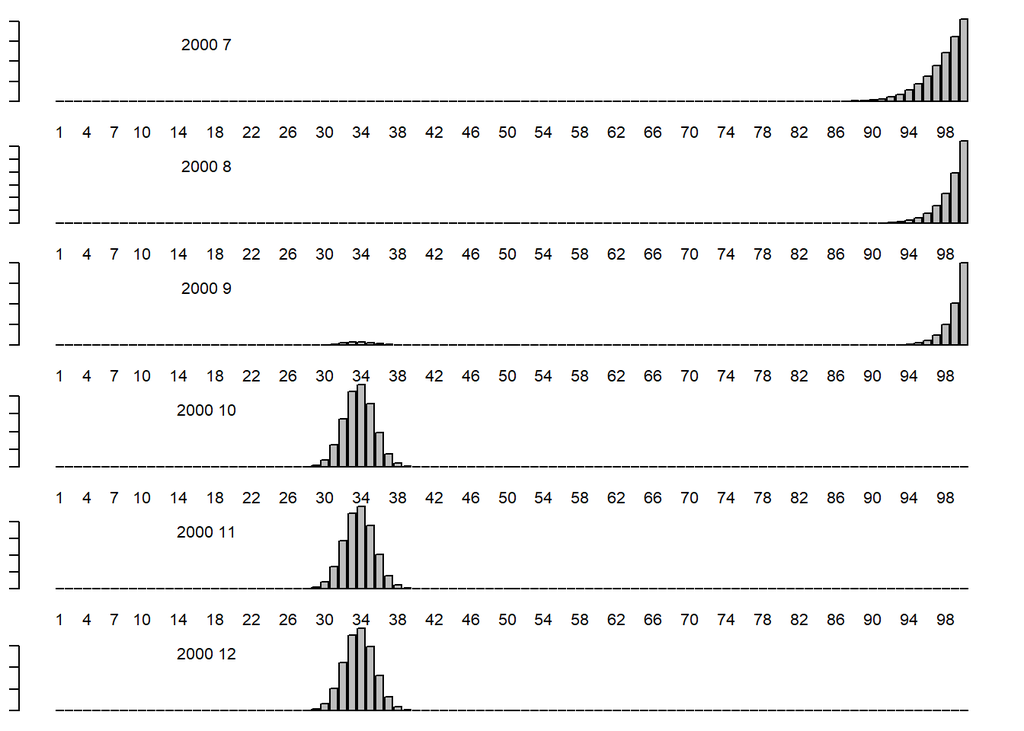

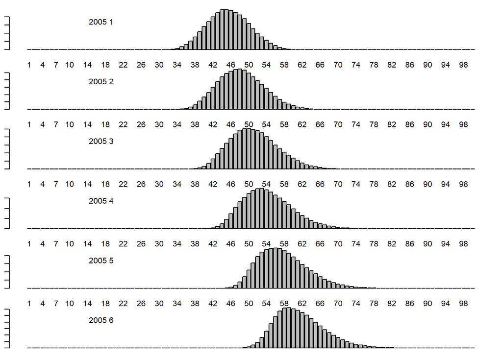

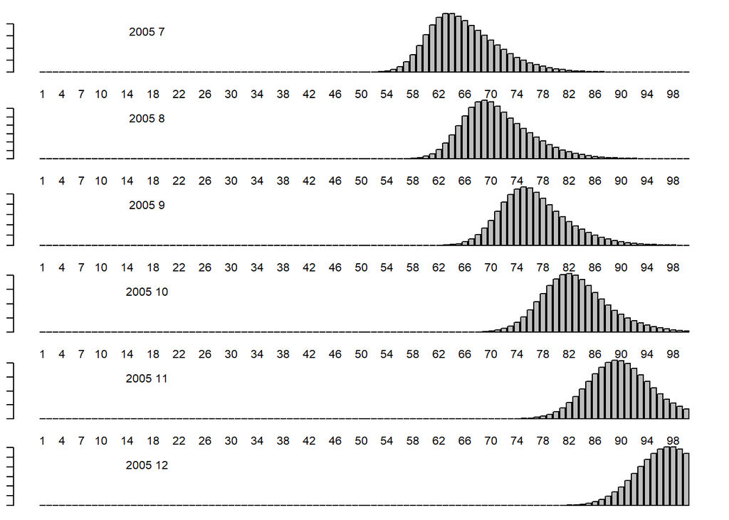

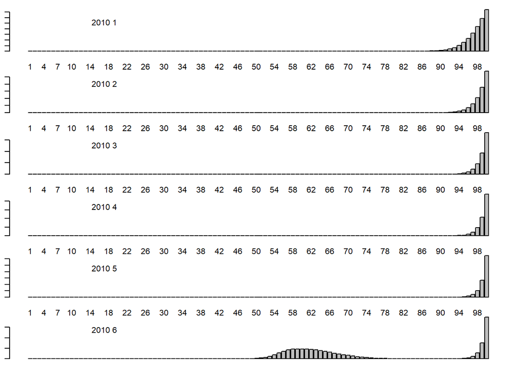

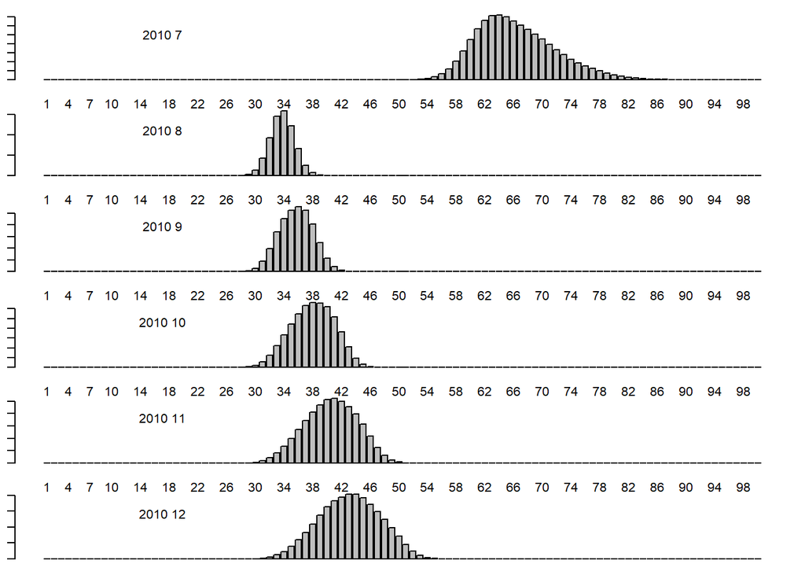

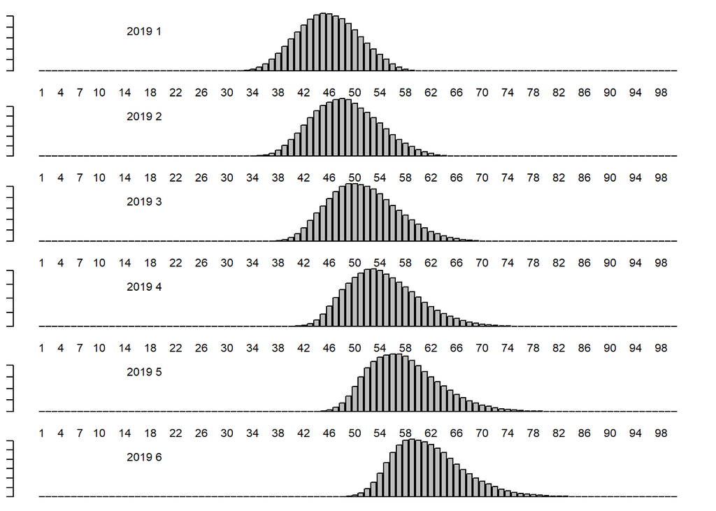

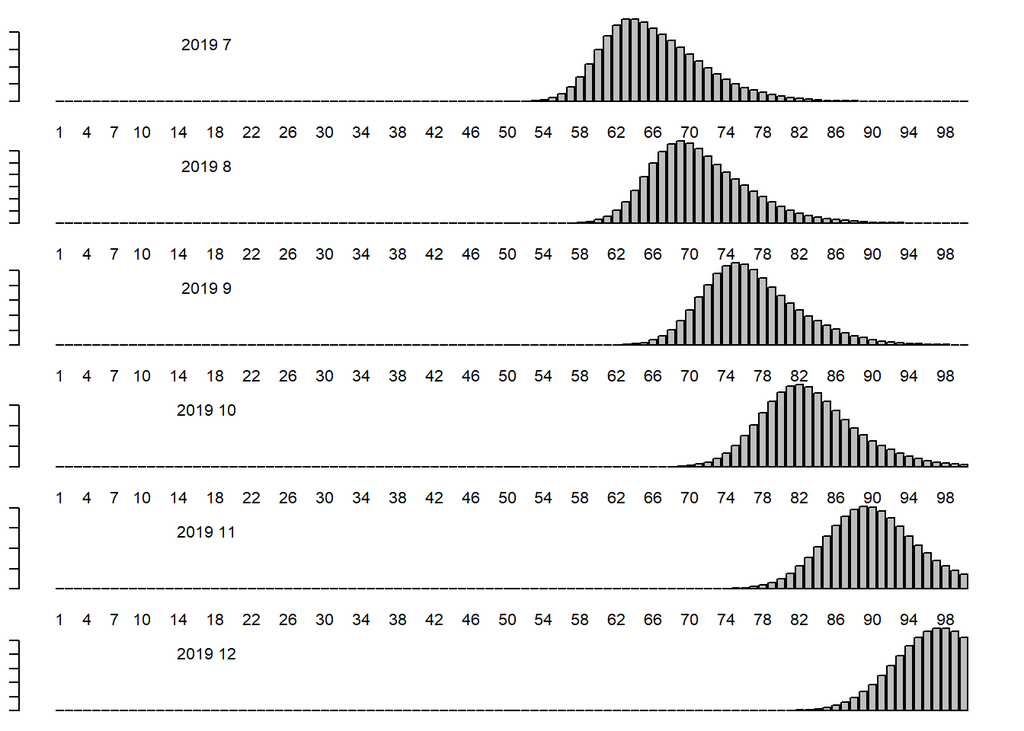

##### 4.2.18.0.1

### 4.2.19 Figure 20. Fleet 2 Catch in number at length by YEAR.MONTH.

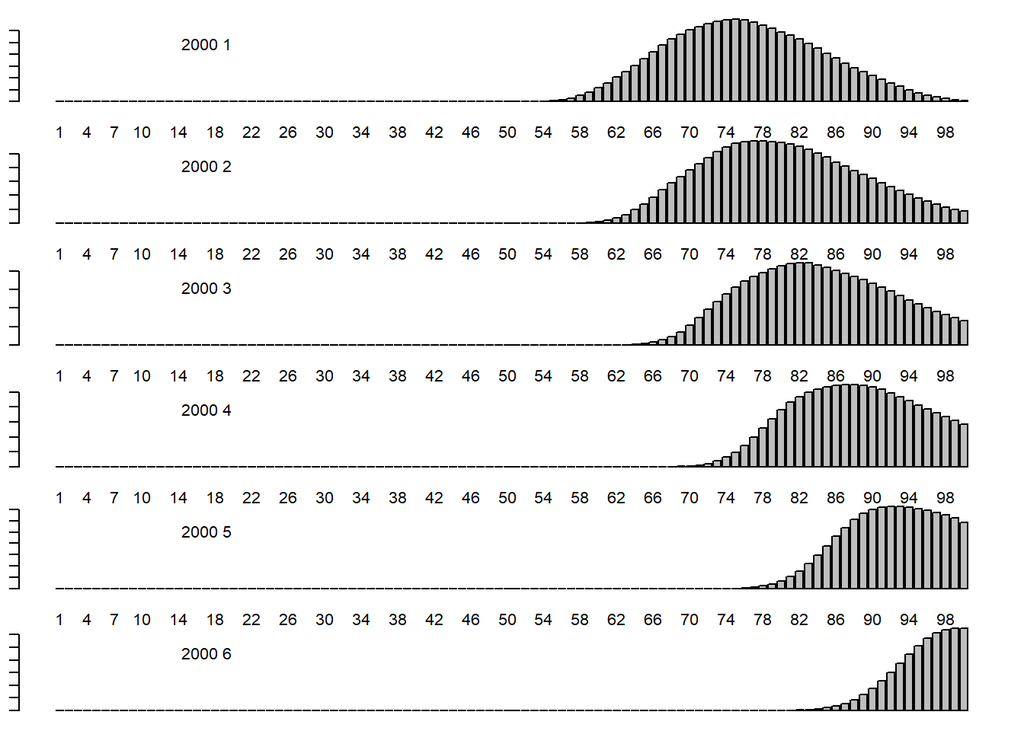

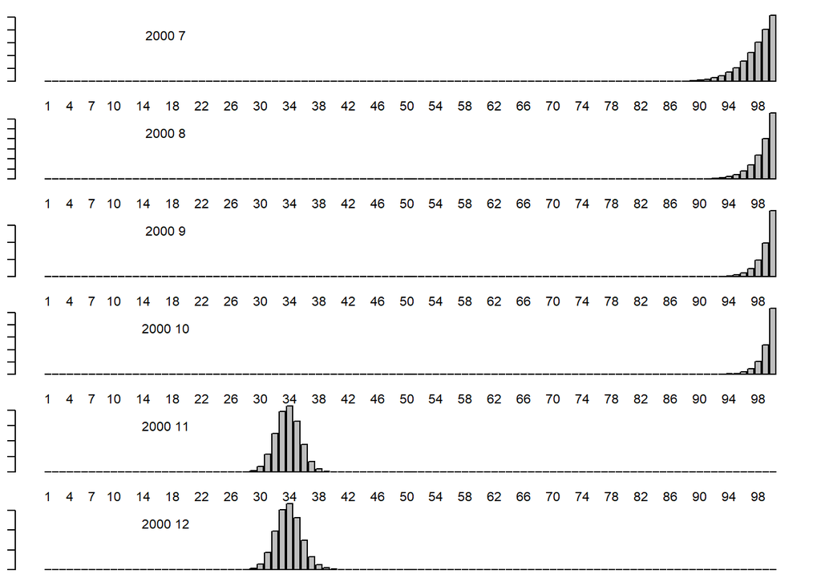

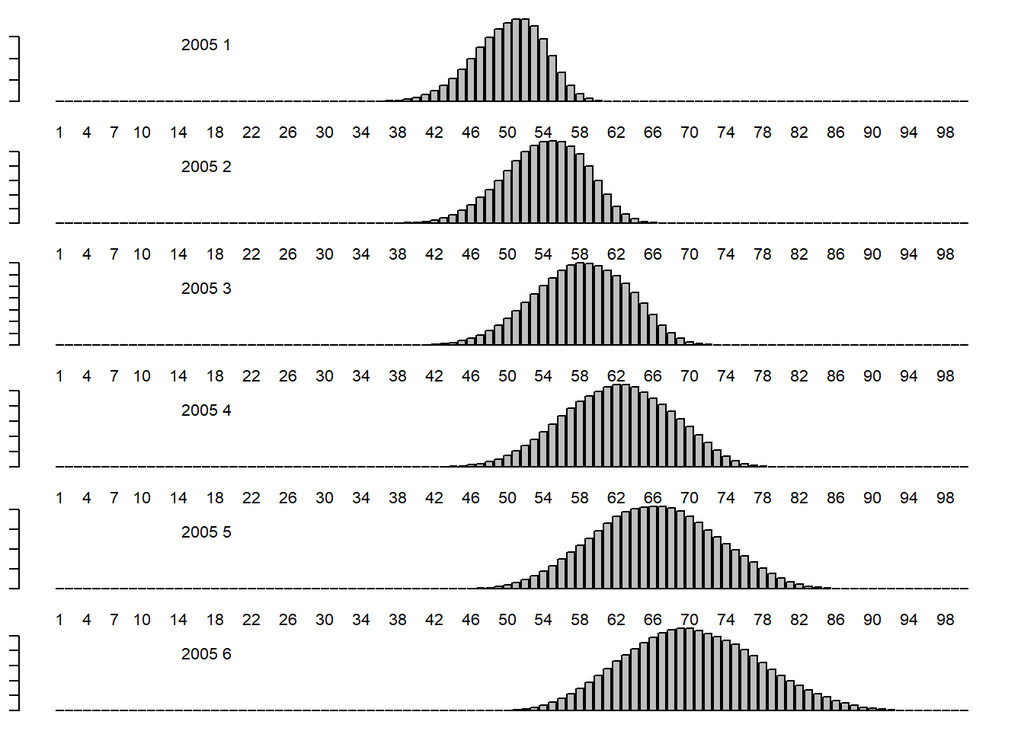

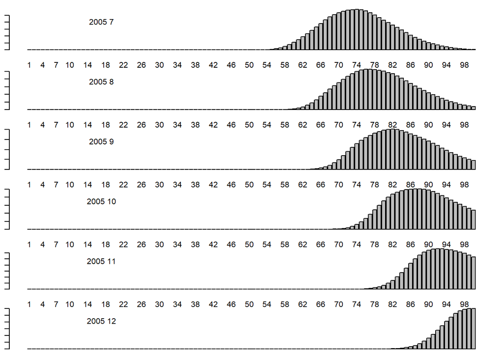

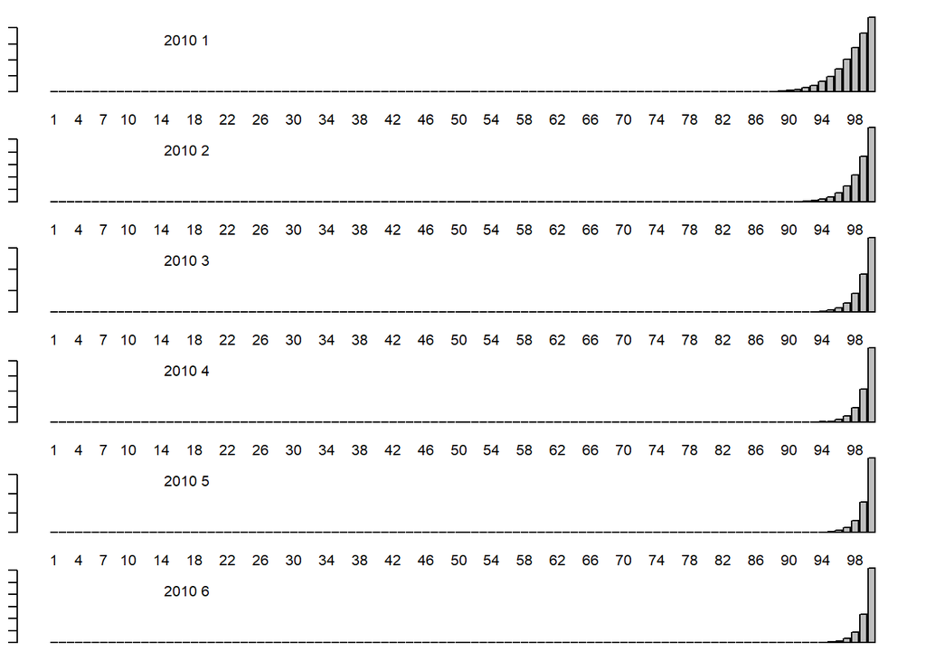

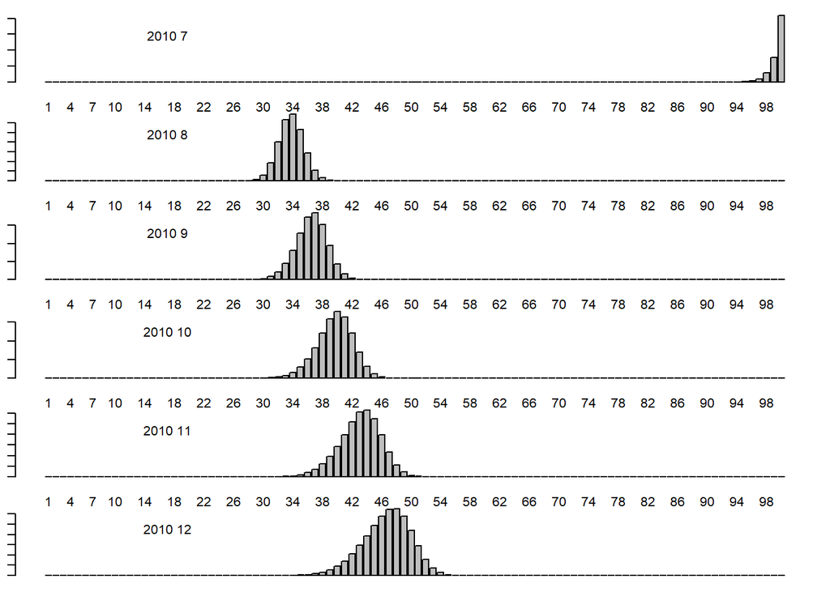

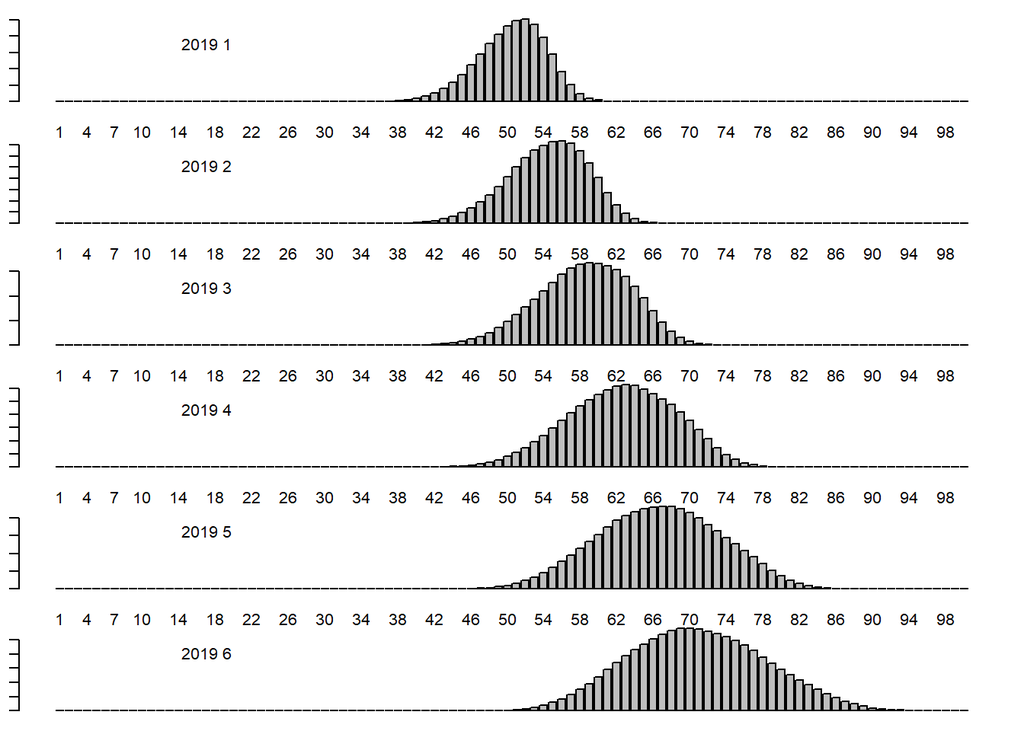

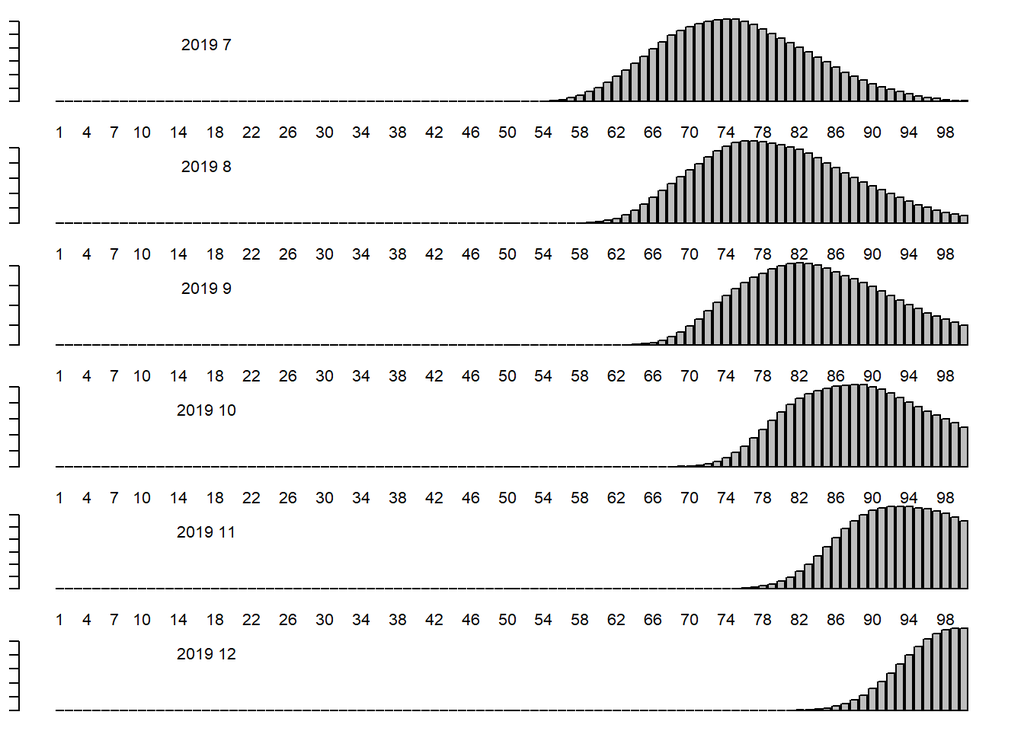